# Rocky Intertidal Biogeochemistry — Exploratory Analysis

Nyssa + Tena

# Overview

This Quarto document:

- Loads and merges pH/TA/nutrients and fDOM datasets
- Cleans data and applies outlier handling (IQR rule)
- Summarizes by habitat and diel period
- Visualizes diel and habitat patterns (boxplots, TA–pH, fDOM heatmap)
- Computes correlation matrices and significance masks
- Runs non-parametric statistics (Kruskal–Wallis, Wilcoxon, Dunn vs. control)
- Performs PCA with scores and loadings plots
- Lists testable hypotheses informed by the exploratory results

> **Reproducibility & Modularity**  
> Kept times (which removes summer), and the control label (open ocean) are parameterized in the YAML `params:` so I can change inputs without editing code chunks.

# Setup

```r
library(tidyverse)
library(patchwork)
library(rstatix)
library(ggcorrplot)
library(ggrepel)
library(here)
library(lubridate)
library(kableExtra)
library(car)
library(emmeans)
library(agricolae)

# Global plot theme
theme_set(theme_bw(base_size = 12))
```

## Paths & Parameters

```r
keep_times <- params$keep_times
control_label <- params$control_label
```

# Data Loading & Merging

This section loads both fDOM and pH/nutrients CSVs, parses dates, and joins on shared identifiers. We keep all samples, regarless of missing data (`full_join`).

```r
load_ok <- TRUE
tryCatch({
  data_ph <- read_csv(here::here("Data","Biogeochemistry","pHProbe_Data_calculated_oo.csv"), na = c("NA", ""), show_col_types = FALSE) %>%
    mutate(Sampling_Date = lubridate::mdy(Sampling_Date))
  data_fdom <- read_csv(here::here("Data","Biogeochemistry","fDOM_clean_oo.csv"), na = c("NA", ""), show_col_types = FALSE) %>%
    mutate(Sampling_Date = lubridate::mdy(Sampling_Date))

  data_merged <- full_join(
    data_ph,
    data_fdom,
    by = c("UniqueID", "Benthos", "Quad_ID", "Day_Night", "Sampling_Date", "Sampling_Time","Season")
  ) %>%
    mutate(Humic = UVHumic+VisibleHumic+MarineHumic,# make a column for humics
           Prot = Tryptophan+Tyrosine, # make a column for proteinaceaus fDOM
           Nitrogen = NO3+NO2 # make a column of total N
           )

  cat("Data loaded and merged successfully.\n")
  cat("Total merged samples:", nrow(data_merged), "\n")
}, error = function(e){
  load_ok <<- FALSE
  message("Error loading or merging files. Please check file paths and names.")
  message(e)
})
```

```
## Data loaded and merged successfully.
## Total merged samples: 333
```

```r
stopifnot(load_ok)
```

# Cleaning & Pre-processing

We declare variable sets for identifiers, water chemistry, nutrients, and fDOM components. We retain only **Dawn** and **Dusk** samples, coerce numeric columns, set factor orders, drop NA grouping levels, and apply the **1.5×IQR rule** as a conservative outlier filter (replacing outliers with `NA`).

```r
# Identifier variables
id_vars <- c("UniqueID", "Season", "Benthos", "Quad_ID", "Day_Night", "Sampling_Date")

# Water chemistry variables (from pH probe file)
water_chem_vars <- c("Salinity", "pH", "TempInSitu", "TA")

# Nutrient variables (from pH probe file)
nutrient_vars <- c("NO3", "PO4", "SIL", "NO2", "NH4", "Nitrogen")

# fDOM variables (from fDOM file)
#fdom_vars <- c("UVHumic", "Tyrosine", "VisibleHumic", "MarineHumic",
#               "Tryptophan", "FulvicAcid", "BIX", "HIX", "FI", "M_to_C")

# reduced variables
fdom_vars <- c("Humic","Prot", "BIX", "HIX", "M_to_C")

all_numeric_vars <- c(water_chem_vars, nutrient_vars, fdom_vars)

# Helper to IQR-filter a numeric vector (returning NA for outliers)
iqr_filter <- function(x){
  if(!is.numeric(x)) return(x)
  q1 <- quantile(x, 0.25, na.rm = TRUE)
  q3 <- quantile(x, 0.75, na.rm = TRUE)
  iqr <- q3 - q1
  lo <- q1 - 1.5 * iqr
  hi <- q3 + 1.5 * iqr
  ifelse(x < lo | x > hi, NA_real_, x)
}

# Cleaned dataset
data_clean <- data_merged %>%
  filter(Day_Night %in% keep_times) %>%
  select(all_of(id_vars), any_of(all_numeric_vars)) %>%
  mutate(across(all_of(all_numeric_vars), as.numeric)) %>%
  mutate(
    Benthos   = factor(Benthos, levels = c(control_label, "Rockweed", "Surfgrass", "Barnacle", "Mussel")),
    Day_Night = factor(Day_Night, levels = c("Dawn", "Dusk"))
  ) %>%
  drop_na(Benthos, Day_Night) %>%
  mutate(across(all_of(all_numeric_vars), iqr_filter))
```

# Summary Statistics

Per habitat × diel period (and Season), we compute mean, SD, and sample size for all numeric variables.

```r
data_summary <- data_clean %>%
  group_by(Benthos, Day_Night, Season) %>%
  summarise(
    across(all_of(all_numeric_vars), list(mean = ~ mean(., na.rm = TRUE),
                                          sd   = ~ sd(., na.rm = TRUE),
                                          n    = ~ sum(!is.na(.))
    )),
    .groups = "drop"
  )

data_summary %>%
  kable()
```

| Benthos | Day_Night | Season | Salinity_mean | Salinity_sd | Salinity_n | pH_mean | pH_sd | pH_n | TempInSitu_mean | TempInSitu_sd | TempInSitu_n | TA_mean | TA_sd | TA_n | NO3_mean | NO3_sd | NO3_n | PO4_mean | PO4_sd | PO4_n | SIL_mean | SIL_sd | SIL_n | NO2_mean | NO2_sd | NO2_n | NH4_mean | NH4_sd | NH4_n | … |
| --- | --- | --- | --- | --- | --- | --- | --- | --- | --- | --- | --- | --- | --- | --- | --- | --- | --- | --- | --- | --- | --- | --- | --- | --- | --- | --- | --- | --- | --- | --- |
| Open Ocean | Dawn | Fall | 33.38100 | 0.3603054 | 20 | 7.895841 | 0.0370698 | 20 | 16.69300 | 0.3202483 | 20 | 2219.689 | 5.182439 | 18 | 1.8750000 | 1.7364249 | 8 | 0.3850000 | 0.0424264 | 8 | 4.662500 | 0.8331309 | 8 | 0.1512500 | 0.0405101 | 8 | 1.2000000 | 0.3291548 | 8 | … |
| Open Ocean | Dawn | Spring | 33.47100 | 0.5936975 | 10 | 7.881854 | 0.0402283 | 12 | 14.71333 | 0.6306466 | 12 | 2225.683 | 8.358783 | 12 | 4.5366667 | 1.7531910 | 12 | 0.5872727 | 0.0835573 | 11 | 6.633333 | 2.0096736 | 12 | 0.1775000 | 0.0467343 | 12 | 1.4545455 | 0.4009081 | 11 | … |
| Open Ocean | Dusk | Fall | 33.36208 | 0.2874775 | 24 | 8.090490 | 0.0533197 | 24 | 19.02560 | 0.7991823 | 25 | 2203.024 | 8.944417 | 23 | 2.2522222 | 1.0532423 | 9 | 0.4255556 | 0.0777996 | 9 | 5.233333 | 0.9486833 | 9 | 0.2122222 | 0.1209109 | 9 | 1.2300000 | 0.8075713 | 8 | … |
| Open Ocean | Dusk | Spring | 33.37125 | 0.3949842 | 8 | 8.245637 | 0.0748407 | 9 | 15.54667 | 0.7608219 | 9 | 2217.774 | 14.150148 | 9 | 4.9225000 | 2.7673027 | 8 | 0.7100000 | 0.1690309 | 8 | 8.260000 | 2.0851858 | 5 | 0.2844444 | 0.1248110 | 9 | 1.5825000 | 0.4803198 | 8 | … |
| Rockweed | Dawn | Fall | 33.41400 | 0.2791336 | 10 | 7.877666 | 0.0321614 | 10 | 16.82917 | 0.3819438 | 12 | 2191.153 | 21.010648 | 9 | 0.9685714 | 1.0548369 | 7 | 0.4371429 | 0.1914606 | 7 | 5.242857 | 0.5563486 | 7 | 0.1714286 | 0.1359447 | 7 | 0.8257143 | 0.5333810 | 7 | … |
| Rockweed | Dawn | Spring | 33.64222 | 0.4889728 | 9 | 7.855984 | 0.0778063 | 9 | 14.40222 | 0.1141028 | 9 | 2206.656 | 15.635454 | 8 | 1.5600000 | 0.6988920 | 5 | 0.5383333 | 0.1402022 | 6 | 5.360000 | 1.1865918 | 5 | 0.1500000 | 0.0547723 | 5 | 1.1175000 | 0.1615292 | 4 | … |
| Rockweed | Dusk | Fall | 33.49200 | 0.2987809 | 5 | 8.049176 | 0.0397228 | 5 | 18.38667 | 0.6511426 | 6 | 2192.423 | 37.722771 | 4 | 1.1050000 | 0.9965691 | 6 | 0.3900000 | 0.0460435 | 6 | 5.840000 | 1.9654516 | 5 | 0.1583333 | 0.0773089 | 6 | 0.8880000 | 0.2348829 | 5 | … |
| Rockweed | Dusk | Spring | 33.41000 | 0.4397727 | 8 | 8.179804 | 0.1405340 | 8 | 15.94500 | 0.6891610 | 8 | 2215.180 | 14.283947 | 6 | 5.2940000 | 2.0029054 | 5 | 0.6033333 | 0.0917969 | 6 | 8.800000 | 2.5455844 | 2 | 0.3300000 | 0.1383835 | 5 | 1.4000000 | 0.3459769 | 3 | … |
| Surfgrass | Dawn | Fall | 33.39286 | 0.1648953 | 7 | 7.897631 | 0.1088502 | 7 | 16.78556 | 0.3758028 | 9 | 2213.461 | 14.812645 | 3 | 0.6333333 | 0.1938728 | 6 | 0.3216667 | 0.0515429 | 6 | 5.350000 | 0.8916277 | 6 | 0.1133333 | 0.0791623 | 6 | 0.6683333 | 0.4844550 | 6 | … |
| Surfgrass | Dawn | Spring | 33.56750 | 0.4792181 | 8 | 7.868478 | 0.0467848 | 10 | 14.36167 | 0.2132789 | 12 | 2212.029 | 10.789451 | 10 | 1.3237500 | 0.3048155 | 8 | 0.4933333 | 0.0578792 | 9 | 5.666667 | 1.1169154 | 9 | 0.1544444 | 0.0371184 | 9 | 1.0137500 | 0.2107766 | 8 | … |
| Surfgrass | Dusk | Fall | 33.36000 | 0.1719011 | 9 | 8.088297 | 0.0523523 | 9 | 18.89917 | 0.7730160 | 12 | 2190.994 | 14.877382 | 8 | 0.4925000 | 0.3192290 | 8 | 0.3887500 | 0.1446609 | 8 | 4.650000 | 1.1389218 | 8 | 0.1112500 | 0.0429077 | 8 | 0.8150000 | 0.5741341 | 6 | … |
| Surfgrass | Dusk | Spring | 33.44100 | 0.4400114 | 10 | 8.041989 | 0.1386101 | 10 | 14.87909 | 0.5579687 | 11 | 2206.070 | 19.112551 | 8 | 5.6830000 | 2.1019306 | 10 | 0.6980000 | 0.1103328 | 10 | 10.950000 | 1.8110770 | 8 | 0.3380000 | 0.0755425 | 10 | 1.2600000 | 0.4355074 | 10 | … |
| Barnacle | Dawn | Fall | 33.44250 | 0.1875976 | 8 | 7.904071 | 0.0231209 | 8 | 17.10556 | 0.3453662 | 9 | 2186.368 | 12.876338 | 7 | 1.0362500 | 0.8035624 | 8 | 0.3287500 | 0.0664267 | 8 | 3.887500 | 0.4998214 | 8 | 0.1912500 | 0.1101217 | 8 | 1.3262500 | 0.5783706 | 8 | … |
| Barnacle | Dawn | Spring | 33.47556 | 0.5347455 | 9 | 7.893685 | 0.0377390 | 11 | 14.71538 | 0.6333721 | 13 | 2221.374 | 15.454368 | 8 | 2.0525000 | 1.2563638 | 8 | 0.4625000 | 0.0462138 | 8 | 5.675000 | 2.3236363 | 8 | 0.1637500 | 0.0552753 | 8 | 1.3112500 | 0.4398194 | 8 | … |
| Barnacle | Dusk | Fall | 33.34125 | 0.2042714 | 8 | 8.038811 | 0.0733546 | 8 | 18.67909 | 0.9594212 | 11 | 2189.224 | 17.012351 | 7 | 0.9020000 | 0.7003777 | 10 | 0.3880000 | 0.0561348 | 10 | 4.490000 | 0.6261878 | 10 | 0.1820000 | 0.0928320 | 10 | 0.9550000 | 0.5188173 | 8 | … |
| Barnacle | Dusk | Spring | 33.64714 | 0.4252859 | 14 | 8.202076 | 0.0841076 | 14 | 15.37933 | 0.7513366 | 15 | 2201.395 | 11.875585 | 11 | 3.6777778 | 2.3006672 | 9 | 0.5622222 | 0.0881445 | 9 | 9.037500 | 2.6370641 | 8 | 0.2444444 | 0.1094430 | 9 | 0.9433333 | 0.3011229 | 9 | … |
| Mussel | Dawn | Fall | 33.53000 | 0.2606147 | 6 | 7.897666 | 0.0185127 | 6 | 17.24714 | 0.1742330 | 7 | 2202.115 | 20.563508 | 6 | 0.9700000 | 0.3880722 | 5 | 0.3000000 | 0.0452769 | 5 | 4.020000 | 0.3193744 | 5 | 0.1520000 | 0.0454973 | 5 | 0.9280000 | 0.3692831 | 5 | … |
| Mussel | Dawn | Spring | 33.61067 | 0.3814159 | 15 | 7.866524 | 0.0602747 | 15 | 14.95105 | 0.6214669 | 19 | 2216.107 | 23.421643 | 12 | 2.0066667 | 0.6075154 | 9 | 0.5575000 | 0.1212730 | 8 | 6.144444 | 1.3947322 | 9 | 0.1755556 | 0.0534114 | 9 | 1.3275000 | 0.4642582 | 8 | … |
| Mussel | Dusk | Fall | 33.48125 | 0.1833371 | 8 | 8.082125 | 0.0388314 | 8 | 19.73125 | 0.3826762 | 8 | 2194.209 | 19.112938 | 7 | 0.7316667 | 0.5541630 | 6 | 0.2460000 | 0.1297305 | 5 | 4.333333 | 1.5331884 | 6 | 0.1480000 | 0.1175585 | 5 | 1.0650000 | 0.6507457 | 6 | … |
| Mussel | Dusk | Spring | 33.57158 | 0.4624003 | 19 | 8.156956 | 0.1116214 | 19 | 15.28000 | 0.8648882 | 20 | 2200.295 | 19.221109 | 17 | 4.0466667 | 1.7320470 | 6 | 0.6700000 | 0.0864870 | 6 | 10.350000 | 1.8218123 | 6 | 0.2983333 | 0.1132107 | 6 | 1.2180000 | 0.3126020 | 5 | … |

# Diel & Habitat Visualizations

A helper function produces publication-ready boxplots with jitter, faceted by **Season × Benthos**.

```r
#' Create diel (Dawn vs Dusk) boxplot faceted by Season × Benthos
#' @param var_to_plot Column name (string)
#' @param var_label  Y-axis label (string)
plot_diel_comparison <- function(var_to_plot, var_label){
  stopifnot(var_to_plot %in% names(data_clean))

  data_clean %>%
    filter(!is.na(.data[[var_to_plot]])) %>%
    ggplot(aes(x = Day_Night, y = .data[[var_to_plot]], fill = Day_Night)) +
    geom_boxplot(outlier.shape = NA) +
    geom_jitter(width = 0.15, alpha = 0.5, size = 2) +
    facet_wrap(Season ~ Benthos,
              # scales = "free_y",
               ncol = 5) +
    scale_fill_manual(values = c("Dawn" = "#FDB813", "Dusk" = "#003865")) +
    labs(title = paste("Diel Patterns in", var_label), x = "Time of Day", y = var_label) +
    theme(legend.position = "none", strip.background = element_rect(fill = "grey90"),
          axis.text.x = element_text(angle = 45, hjust = 1))
}
```

## Example Diel Plots

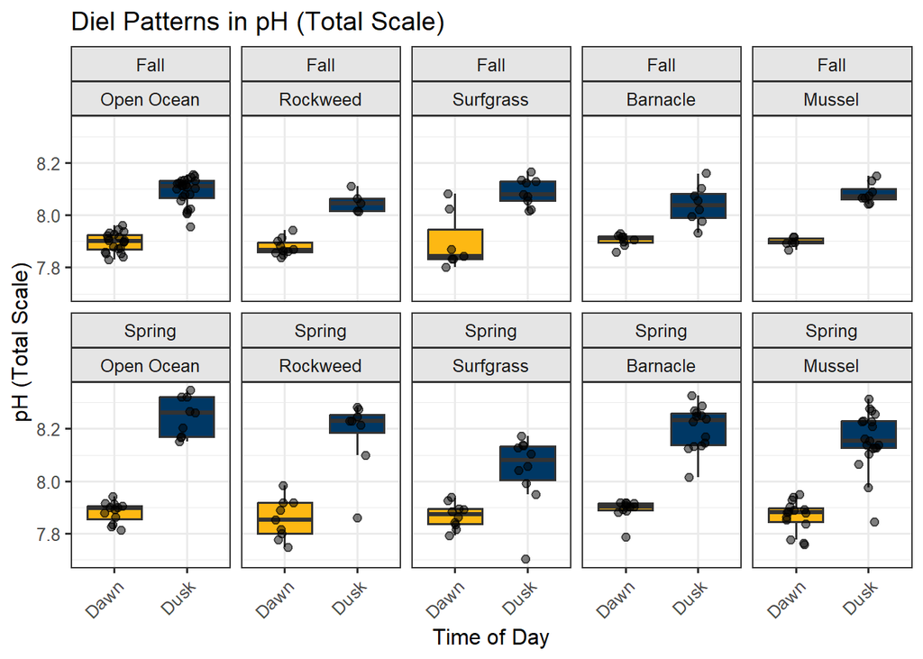

Diel (Dawn vs Dusk) differences by Season × Benthos for selected variables.

```r
(p_ph  <- plot_diel_comparison("pH",         "pH (Total Scale)"))
```

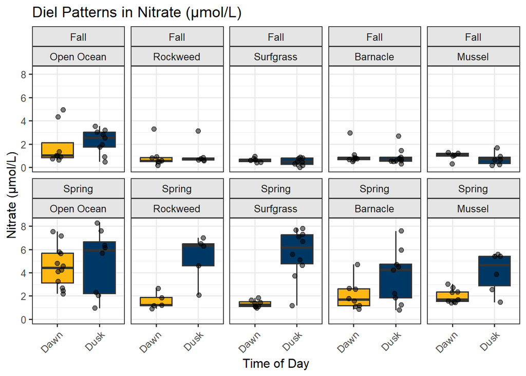

Diel (Dawn vs Dusk) differences by Season × Benthos for selected variables.

```r
(p_no3 <- plot_diel_comparison("NO3",        "Nitrate (µmol/L)"))
```

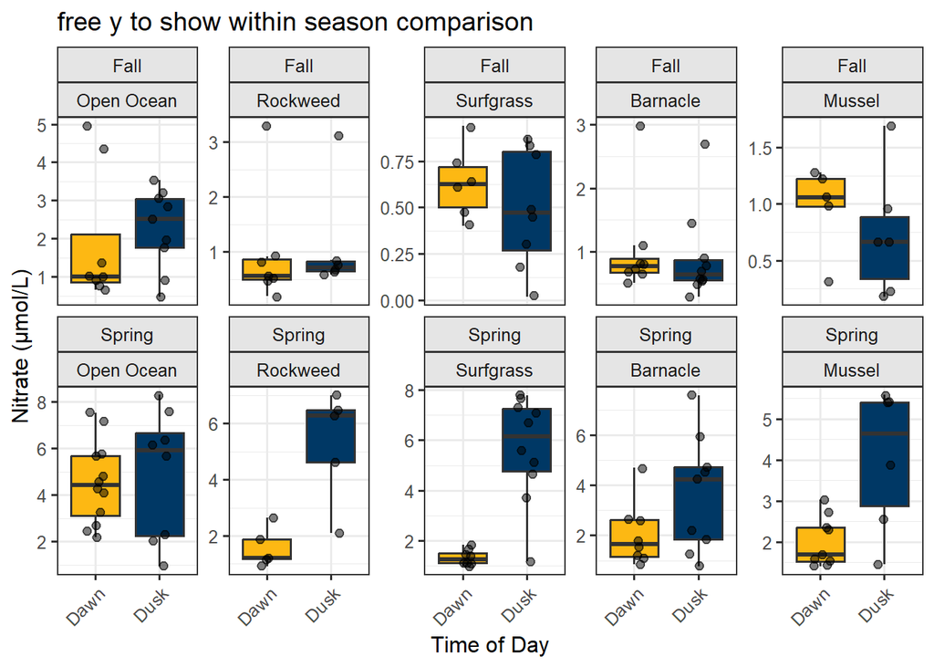

Diel (Dawn vs Dusk) differences by Season × Benthos for selected variables.

```r
(p_no3 <- plot_diel_comparison("NO3",        "Nitrate (µmol/L)")+
    facet_wrap(Season~Benthos, scales = "free_y", ncol = 5)+
    labs(title = "free y to show within season comparison")) # show it again but with free y
```

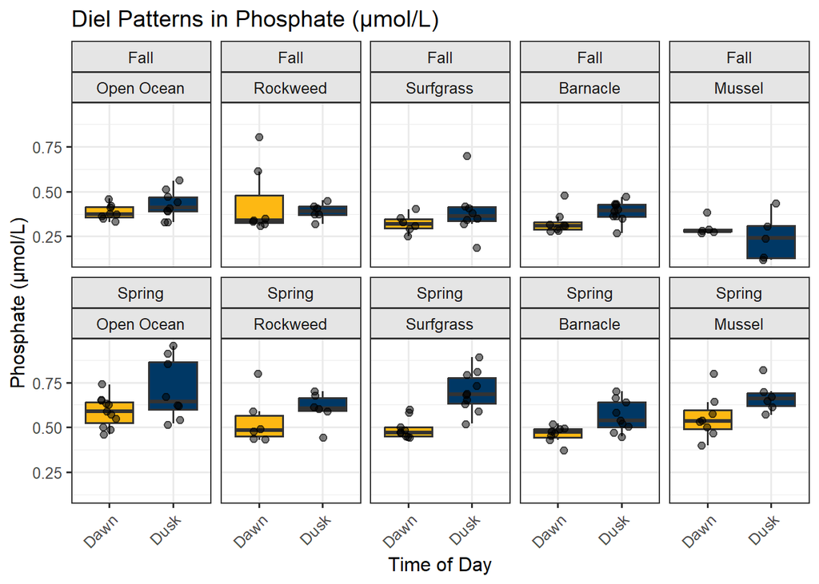

Diel (Dawn vs Dusk) differences by Season × Benthos for selected variables.

```r
#(p_trp <- plot_diel_comparison("Tryptophan", "Tryptophan-like fDOM (RFU)"))
(p_po4 <- plot_diel_comparison("PO4",        "Phosphate (µmol/L)"))
```

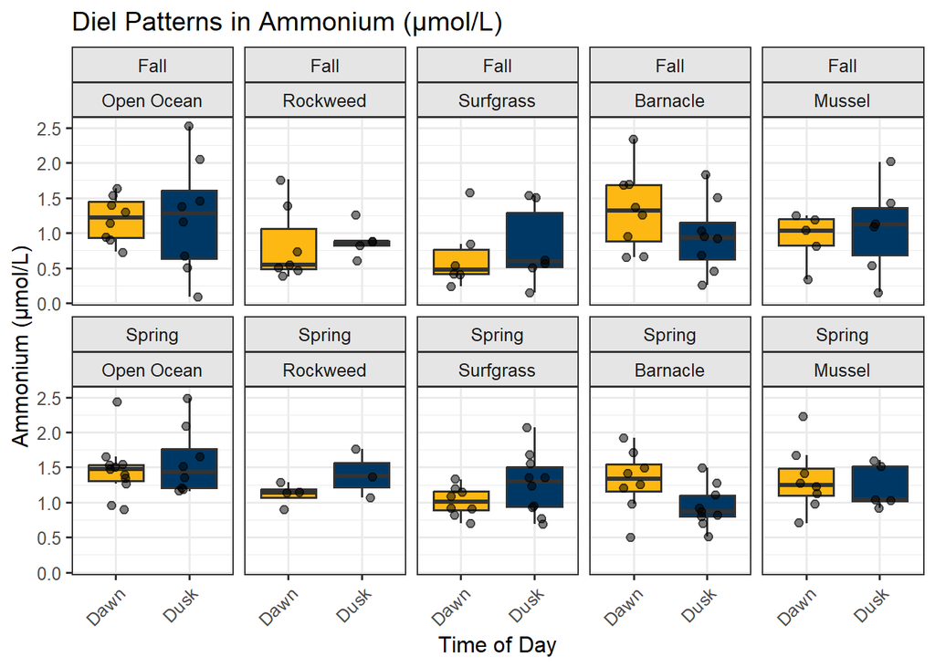

Diel (Dawn vs Dusk) differences by Season × Benthos for selected variables.

```r
(p_nh4 <- plot_diel_comparison("NH4",        "Ammonium (µmol/L)"))
```

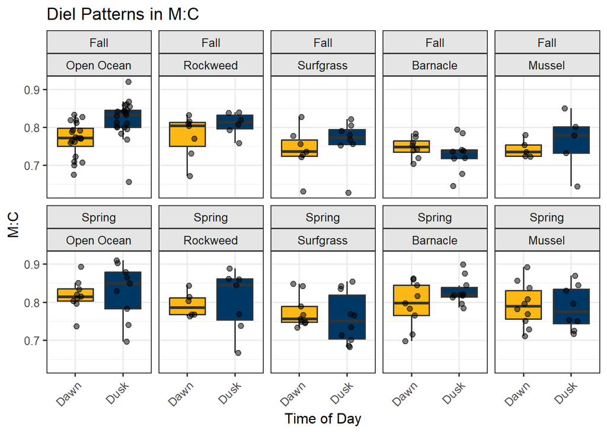

Diel (Dawn vs Dusk) differences by Season × Benthos for selected variables.

```r
(p_mc  <- plot_diel_comparison("M_to_C",     "M:C"))
```

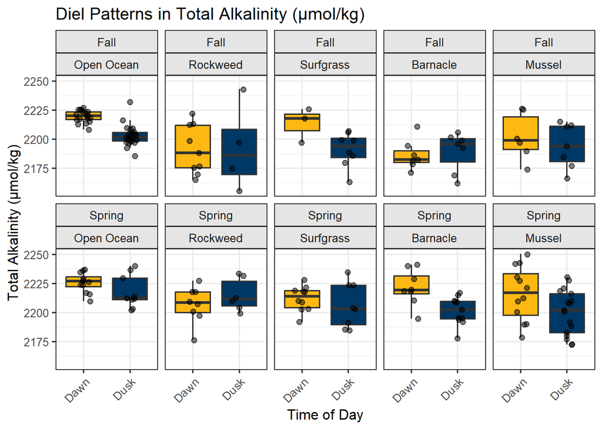

Diel (Dawn vs Dusk) differences by Season × Benthos for selected variables.

```r
(p_TA  <- plot_diel_comparison("TA",     "Total Alkalinity (µmol/kg)"))
```

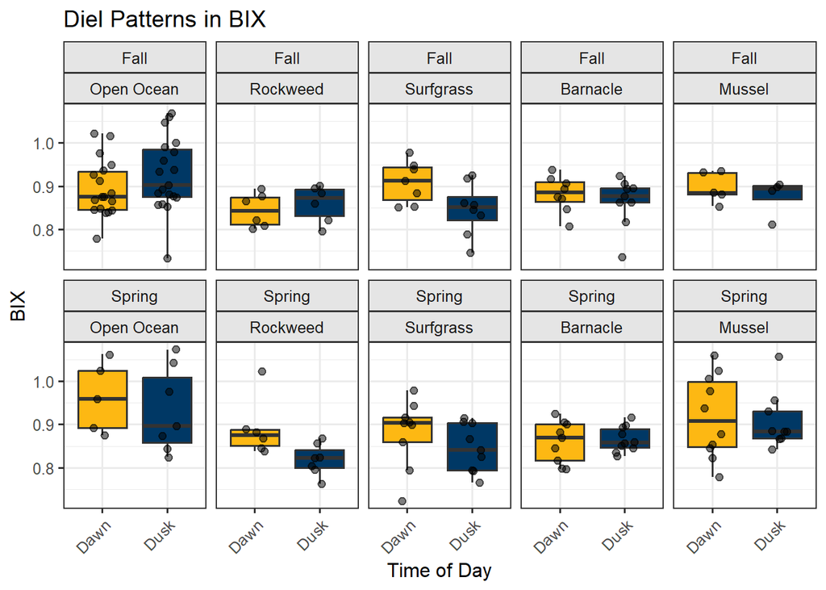

Diel (Dawn vs Dusk) differences by Season × Benthos for selected variables.

```r
(p_bix  <- plot_diel_comparison("BIX",     "BIX"))
```

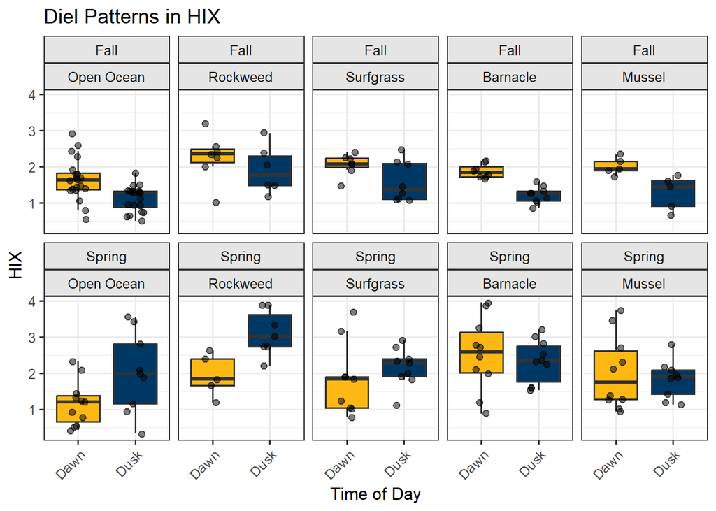

Diel (Dawn vs Dusk) differences by Season × Benthos for selected variables.

```r
(p_hix  <-(p_bix  <- plot_diel_comparison("HIX",     "HIX")))
```

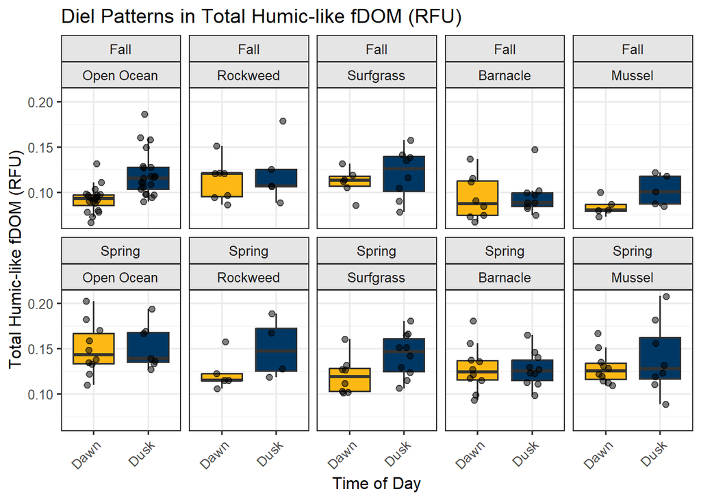

Diel (Dawn vs Dusk) differences by Season × Benthos for selected variables.

```r
(p_humic  <- plot_diel_comparison("Humic",     "Total Humic-like fDOM (RFU)"))
```

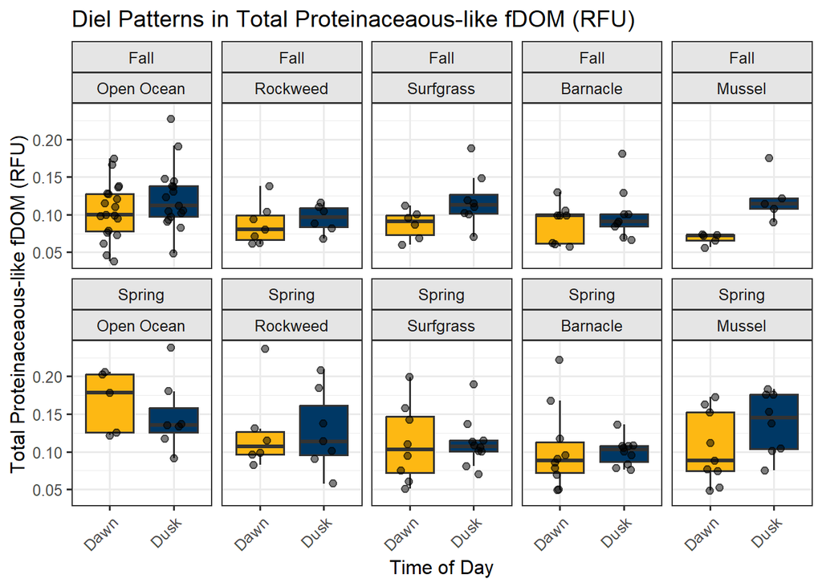

Diel (Dawn vs Dusk) differences by Season × Benthos for selected variables.

```r
(p_prot  <- plot_diel_comparison("Prot",     "Total Proteinaceaous-like fDOM (RFU)"))
```

# Carbonate & fDOM Patterns

## Carbonate Chemistry (pH vs TA)

Interpret vectors: **Respiration** ↓pH (TA ~ constant), **Photosynthesis** ↑pH (TA ~ constant), **Calcification** ↓TA & ↓pH, **Dissolution** ↑TA & ↑pH.

[figure not shown]

Carbonate chemistry scatter: pH vs Total Alkalinity, colored by habitat and shaped by diel period.

```r
data_clean %>%
  ggplot(aes(x = pH, y = TA, color = Benthos, shape = Day_Night)) +
  geom_point(size = 3.5, alpha = 0.8) +
  scale_color_brewer(palette = "Set1") +
  facet_wrap(~ Season) +
  labs(title = "Carbonate Chemistry: pH vs. Total Alkalinity",
       x = "Total Alkalinity (µmol/kg)", y = "pH (Total Scale)",
       color = "Habitat", shape = "Time of Day") +
  theme(legend.position = "right")
```

## fDOM and Nutrient Heatmap

We compute mean values by **Benthos × Day_Night × Season**, then z-scale **within each fDOM or nutrient component** to compare relative patterns.

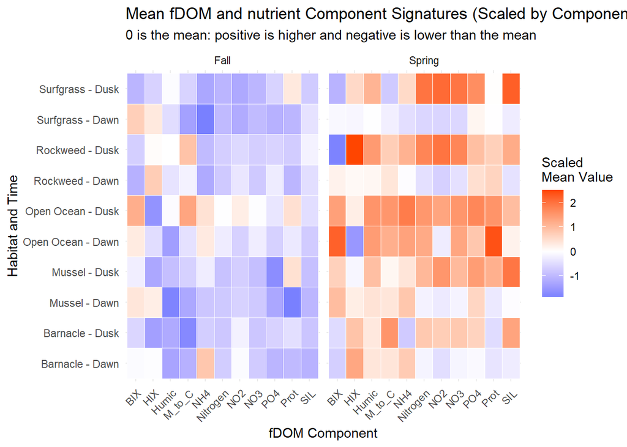

Scaled mean fDOM component signatures across habitats and times.

```r
fdom_heatmap_data <- data_clean %>%
  group_by(Benthos, Day_Night, Season) %>%
  summarise(across(all_of(c(fdom_vars, nutrient_vars)), ~ mean(., na.rm = TRUE)), .groups = "drop") %>%
  pivot_longer(cols = all_of(c(fdom_vars, nutrient_vars)), names_to = "fDOM_Component", values_to = "Mean_Value") %>%
  group_by(fDOM_Component) %>%
  mutate(Mean_Value_Scaled = as.numeric(scale(Mean_Value))) %>%
  ungroup()

fdom_heatmap_data %>%
  ggplot(aes(x = fDOM_Component, y = paste(Benthos, Day_Night, sep = " - "), fill = Mean_Value_Scaled)) +
  geom_tile(color = "white") +
  scale_fill_gradient2(low = "#075AFF", mid = "white", high = "#FF4500", midpoint = 0, name = "Scaled
Mean Value") +
  labs(title = "Mean fDOM and nutrient Component Signatures (Scaled by Component)", x = "fDOM Component", y = "Habitat and Time",
       subtitle = "0 is the mean: positive is higher and negative is lower than the mean") +
  theme_minimal() +
  theme(axis.text.x = element_text(angle = 45, hjust = 1))+
  facet_wrap(~Season)
```

# Statistical Comparisons

```r
# calculate Δvariable

dawn_dusk <- map_dfr(all_numeric_vars, function(v){
  data_clean %>%
    group_by(Season, Benthos, Day_Night, Quad_ID) %>%
    summarize(mean = mean(.data[[v]], na.rm = TRUE), .groups = "drop") %>%
    pivot_wider(names_from = Day_Night, values_from = mean) %>%
    mutate(
      Dusk = as.numeric(Dusk),
      Dawn = as.numeric(Dawn),
      delta_diel = Dusk - Dawn,
      variable = v)
  })

# compare with OO
diel_test <- map_dfr(all_numeric_vars, function(v){
dunn_test(delta_diel ~ Benthos, data = dawn_dusk%>% filter(Season == "Fall"), p.adjust.method = "bonferroni") %>%
    mutate(Season = "Fall")
dunn_test(delta_diel ~ Benthos, data = dawn_dusk%>% filter(Season == "Spring"), p.adjust.method = "bonferroni") %>%
    mutate(Season = "Spring")
})

diel_test %>%
  filter(group1 == control_label | group2 == control_label)
```

```
## # A tibble: 60 × 10
##    .y.      group1 group2    n1    n2 statistic      p p.adj p.adj.signif Season
##    <chr>    <chr>  <chr>  <int> <int>     <dbl>  <dbl> <dbl> <chr>        <chr>
##  1 delta_d… Open … Rockw…   108    75    1.67   0.0941 0.941 ns           Spring
##  2 delta_d… Open … Surfg…   108    77    1.71   0.0881 0.881 ns           Spring
##  3 delta_d… Open … Barna…   108    88    0.0547 0.956  1     ns           Spring
##  4 delta_d… Open … Mussel   108    73    0.0333 0.973  1     ns           Spring
##  5 delta_d… Open … Rockw…   108    75    1.67   0.0941 0.941 ns           Spring
##  6 delta_d… Open … Surfg…   108    77    1.71   0.0881 0.881 ns           Spring
##  7 delta_d… Open … Barna…   108    88    0.0547 0.956  1     ns           Spring
##  8 delta_d… Open … Mussel   108    73    0.0333 0.973  1     ns           Spring
##  9 delta_d… Open … Rockw…   108    75    1.67   0.0941 0.941 ns           Spring
## 10 delta_d… Open … Surfg…   108    77    1.71   0.0881 0.881 ns           Spring
## # ℹ 50 more rows
```

*Testing hypothesis 1:* Producer habitats (rockweed/surfgrass) exhibit higher pH and lower DIN (NO3, PO4) at Dusk vs Dawn, relative to the Open Ocean control.

```r
# first compare dawn vs dusk using wilcoxon test

#hyp1-pH <-
  data_clean %>%
    group_by(Benthos, Season) %>%
    wilcox_test(pH ~ Day_Night, p.adjust.method = "bonferroni")
```

```
## # A tibble: 10 × 9
##    Season Benthos    .y.   group1 group2    n1    n2 statistic        p
##  * <chr>  <fct>      <chr> <chr>  <chr>  <int> <int>     <dbl>    <dbl>
##  1 Fall   Open Ocean pH    Dawn   Dusk      20    24         1 2.27e-12
##  2 Spring Open Ocean pH    Dawn   Dusk      12     9         0 6.80e- 6
##  3 Fall   Rockweed   pH    Dawn   Dusk      10     5         0 6.66e- 4
##  4 Spring Rockweed   pH    Dawn   Dusk       9     8         4 9.87e- 4
##  5 Fall   Surfgrass  pH    Dawn   Dusk       7     9         7 7.87e- 3
##  6 Spring Surfgrass  pH    Dawn   Dusk      10    10        10 1.5 e- 3
##  7 Fall   Barnacle   pH    Dawn   Dusk       8     8         0 1.55e- 4
##  8 Spring Barnacle   pH    Dawn   Dusk      11    14         0 4.49e- 7
##  9 Fall   Mussel     pH    Dawn   Dusk       6     8         0 6.66e- 4
## 10 Spring Mussel     pH    Dawn   Dusk      15    19        11 2.10e- 7
```

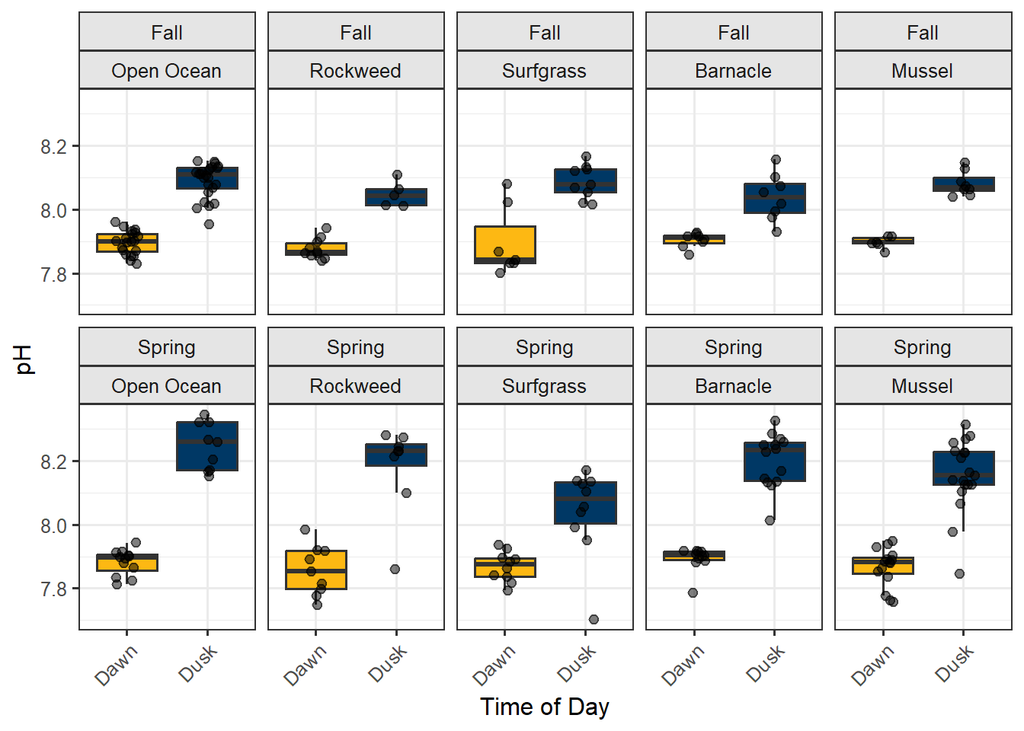

```r
data_clean %>%
    ggplot(aes(x = Day_Night, y = pH, fill = Day_Night)) +
    geom_boxplot(outlier.shape = NA) +
    geom_jitter(width = 0.15, alpha = 0.5, size = 2) +
    facet_wrap(Season ~ Benthos,
               ncol = 5) +
    scale_fill_manual(values = c("Dawn" = "#FDB813", "Dusk" = "#003865")) +
    labs(x = "Time of Day", y = "pH") +
    theme(legend.position = "none", strip.background = element_rect(fill = "grey90"),
          axis.text.x = element_text(angle = 45, hjust = 1))
```

```r
# then compare across benthos using kruskall-wallis on ΔpH

# compute ΔpH
pHChange <- data_clean %>%
  group_by(Season, Benthos, Day_Night) %>%
  summarize(median_pH = median(pH, na.rm = TRUE), .groups = "drop") %>%
  pivot_wider(names_from = Day_Night, values_from = median_pH) %>%
  mutate(deltapH = Dusk - Dawn)

dunn_test(deltapH ~ Benthos, data = pHChange%>% filter(Season == "Fall"), p.adjust.method = "bonferroni")
```

```
## # A tibble: 10 × 9
##    .y.     group1     group2       n1    n2 statistic      p p.adj p.adj.signif
##  * <chr>   <chr>      <chr>     <int> <int>     <dbl>  <dbl> <dbl> <chr>
##  1 deltapH Open Ocean Rockweed      1     1    -0.447 0.655  1     ns
##  2 deltapH Open Ocean Surfgrass     1     1     0.447 0.655  1     ns
##  3 deltapH Open Ocean Barnacle      1     1    -1.34  0.180  1     ns
##  4 deltapH Open Ocean Mussel        1     1    -0.894 0.371  1     ns
##  5 deltapH Rockweed   Surfgrass     1     1     0.894 0.371  1     ns
##  6 deltapH Rockweed   Barnacle      1     1    -0.894 0.371  1     ns
##  7 deltapH Rockweed   Mussel        1     1    -0.447 0.655  1     ns
##  8 deltapH Surfgrass  Barnacle      1     1    -1.79  0.0736 0.736 ns
##  9 deltapH Surfgrass  Mussel        1     1    -1.34  0.180  1     ns
## 10 deltapH Barnacle   Mussel        1     1     0.447 0.655  1     ns
```

```r
dunn_test(deltapH ~ Benthos, data = pHChange%>% filter(Season == "Spring"), p.adjust.method = "bonferroni")
```

```
## # A tibble: 10 × 9
##    .y.     group1     group2       n1    n2 statistic      p p.adj p.adj.signif
##  * <chr>   <chr>      <chr>     <int> <int>     <dbl>  <dbl> <dbl> <chr>
##  1 deltapH Open Ocean Rockweed      1     1     0.447 0.655  1     ns
##  2 deltapH Open Ocean Surfgrass     1     1    -1.34  0.180  1     ns
##  3 deltapH Open Ocean Barnacle      1     1    -0.447 0.655  1     ns
##  4 deltapH Open Ocean Mussel        1     1    -0.894 0.371  1     ns
##  5 deltapH Rockweed   Surfgrass     1     1    -1.79  0.0736 0.736 ns
##  6 deltapH Rockweed   Barnacle      1     1    -0.894 0.371  1     ns
##  7 deltapH Rockweed   Mussel        1     1    -1.34  0.180  1     ns
##  8 deltapH Surfgrass  Barnacle      1     1     0.894 0.371  1     ns
##  9 deltapH Surfgrass  Mussel        1     1     0.447 0.655  1     ns
## 10 deltapH Barnacle   Mussel        1     1    -0.447 0.655  1     ns
```

*Testing hypothesis 2* Upwelling processes will mediate producer response, with stronger responses (in comparison to OO) in spring than in fall.

```r
prod_season <- map_dfr(all_numeric_vars, function(v){
  data_clean %>%
  filter(Benthos == "Rockweed" | Benthos == "Surfgrass" | Benthos == "Open Ocean")%>%
    group_by(Season, Benthos, Day_Night) %>%
    summarize(mean = mean(.data[[v]], na.rm = TRUE), .groups = "drop") %>%
    pivot_wider(names_from = Day_Night, values_from = mean) %>%
    mutate(
      Dusk = as.numeric(Dusk),
      Dawn = as.numeric(Dawn),
      delta_diel = Dusk - Dawn,
      variable = v)
  })

open_season <- prod_season %>%
  filter(Benthos == "Open Ocean") %>%
  rename(oo_diel = "delta_diel") %>%
  select("oo_diel", "Season", "variable") %>%
  filter(!is.na(oo_diel))


prod_season <- prod_season %>%
  left_join(open_season, by = c("Season", "variable")) %>%
  mutate(delta_ocean = delta_diel - oo_diel)


season_test <- map_dfr(all_numeric_vars, function(v){
  prod_season %>%
    filter(variable == v) %>%
    dunn_test(delta_ocean ~ Season, p.adjust.method = "bonferroni") %>%
    mutate(variable = v)
})

season_test
```

```
## # A tibble: 15 × 10
##    .y.   group1 group2    n1    n2 statistic      p  p.adj p.adj.signif variable
##    <chr> <chr>  <chr>  <int> <int>     <dbl>  <dbl>  <dbl> <chr>        <chr>
##  1 delt… Fall   Spring     3     3    -1.33  0.184  0.184  ns           Salinity
##  2 delt… Fall   Spring     3     3    -0.886 0.376  0.376  ns           pH
##  3 delt… Fall   Spring     3     3     0.886 0.376  0.376  ns           TempInS…
##  4 delt… Fall   Spring     3     3     0.443 0.658  0.658  ns           TA
##  5 delt… Fall   Spring     3     3     1.77  0.0765 0.0765 ns           NO3
##  6 delt… Fall   Spring     3     3     0.443 0.658  0.658  ns           PO4
##  7 delt… Fall   Spring     3     3     1.33  0.184  0.184  ns           SIL
##  8 delt… Fall   Spring     3     3     1.77  0.0765 0.0765 ns           NO2
##  9 delt… Fall   Spring     3     3     0.886 0.376  0.376  ns           NH4
## 10 delt… Fall   Spring     3     3     1.77  0.0765 0.0765 ns           Nitrogen
## 11 delt… Fall   Spring     3     3     1.77  0.0765 0.0765 ns           Humic
## 12 delt… Fall   Spring     3     3     1.33  0.184  0.184  ns           Prot
## 13 delt… Fall   Spring     3     3     0.443 0.658  0.658  ns           BIX
## 14 delt… Fall   Spring     3     3    -0.443 0.658  0.658  ns           HIX
## 15 delt… Fall   Spring     3     3     0.886 0.376  0.376  ns           M_to_C
```

*Testing hypothesis 3:* Animal metabolism (mussel/barnacle) will increase NH4+, increase Prot DOM, decrease humics, and decrease pH relative to the open ocean at dawn

```r
# only looking at animals
animal_data <- data_clean %>%
  filter(Benthos == "Mussel" | Benthos == "Barnacle" | Benthos == "Open Ocean")

# test in fall and spring
animal_test <- map_dfr(all_numeric_vars, function(v){

fall <- dunn_test(as.formula(paste(v, " ~ Benthos")), data = animal_data %>%
            filter(Season == "Fall"), p.adjust.method = "bonferroni") %>%
            mutate(Season = "Fall")

spring <- dunn_test(as.formula(paste(v, " ~ Benthos")), data = animal_data %>%
            filter(Season == "Spring"), p.adjust.method = "bonferroni") %>%
            mutate(Season = "Spring")
bind_rows(fall, spring) %>%
  filter(group1 == control_label | group2 == control_label)
})

animal_test <- animal_test %>%
  filter(p.adj < 0.05)

animal_test
```

```
## # A tibble: 16 × 10
##    .y.   group1 group2    n1    n2 statistic       p   p.adj p.adj.signif Season
##    <chr> <chr>  <chr>  <int> <int>     <dbl>   <dbl>   <dbl> <chr>        <chr>
##  1 TA    Open … Barna…    41    14     -4.25 2.10e-5 6.31e-5 ****         Fall
##  2 TA    Open … Mussel    21    29     -2.82 4.86e-3 1.46e-2 *            Spring
##  3 NO3   Open … Barna…    17    18     -2.97 2.97e-3 8.90e-3 **           Fall
##  4 NO3   Open … Mussel    17    11     -2.41 1.62e-2 4.85e-2 *            Fall
##  5 NO3   Open … Barna…    20    17     -2.70 6.98e-3 2.09e-2 *            Spring
##  6 NO3   Open … Mussel    20    15     -2.46 1.41e-2 4.22e-2 *            Spring
##  7 PO4   Open … Mussel    17    10     -3.60 3.13e-4 9.39e-4 ***          Fall
##  8 PO4   Open … Barna…    19    17     -2.98 2.89e-3 8.67e-3 **           Spring
##  9 NH4   Open … Barna…    19    17     -2.61 9.04e-3 2.71e-2 *            Spring
## 10 Nitr… Open … Barna…    17    18     -2.85 4.43e-3 1.33e-2 *            Fall
## 11 Nitr… Open … Barna…    20    17     -2.58 9.89e-3 2.97e-2 *            Spring
## 12 Humic Open … Barna…    17    20     -2.62 8.78e-3 2.63e-2 *            Spring
## 13 Prot  Open … Barna…    12    20     -3.22 1.30e-3 3.89e-3 **           Spring
## 14 BIX   Open … Barna…    12    19     -2.47 1.36e-2 4.09e-2 *            Spring
## 15 HIX   Open … Barna…    20    20      3.16 1.59e-3 4.77e-3 **           Spring
## 16 M_to… Open … Barna…    41    17     -3.80 1.46e-4 4.37e-4 ***          Fall
```

Plots

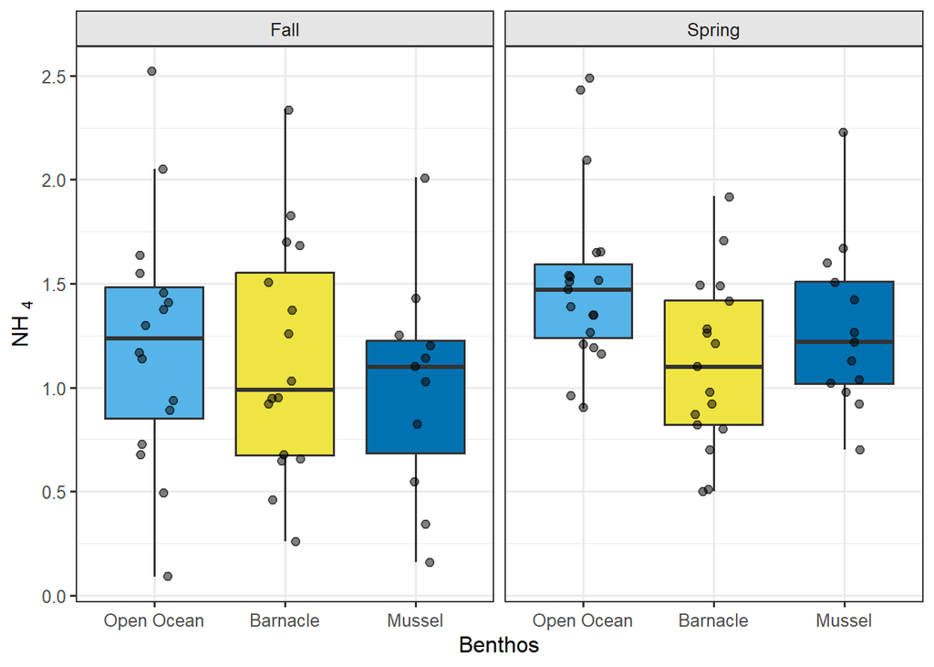

```r
# NH4 plot
animal_data %>%
    ggplot(aes(x = Benthos, y = NH4, fill = Benthos)) +
    geom_boxplot(outlier.shape = NA) +
    geom_jitter(width = 0.15, alpha = 0.5, size = 2) +
    facet_wrap(~Season) +
    scale_fill_manual(values = c("Open Ocean" = "#56B4E9", "Mussel" = "#0072B2", "Barnacle" = "#F0E442")) +
    labs(x = "Benthos", y = expression("NH "[4])) +
    theme(legend.position = "none", strip.background = element_rect(fill = "grey90"))
```

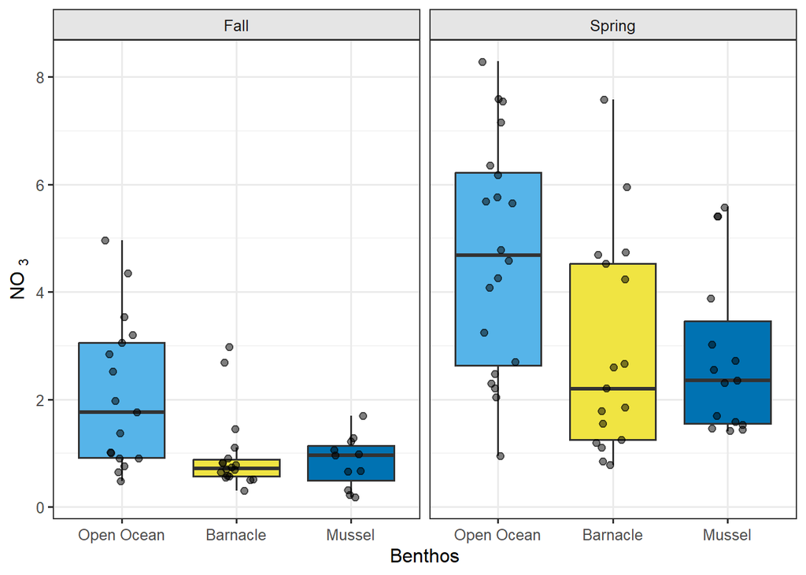

```r
# NO3 plot
animal_data %>%
    ggplot(aes(x = Benthos, y = NO3, fill = Benthos)) +
    geom_boxplot(outlier.shape = NA) +
    geom_jitter(width = 0.15, alpha = 0.5, size = 2) +
    facet_wrap(~Season) +
    scale_fill_manual(values = c("Open Ocean" = "#56B4E9", "Mussel" = "#0072B2", "Barnacle" = "#F0E442")) +
    labs(x = "Benthos", y = expression("NO "[3])) +
    theme(legend.position = "none", strip.background = element_rect(fill = "grey90"))
```

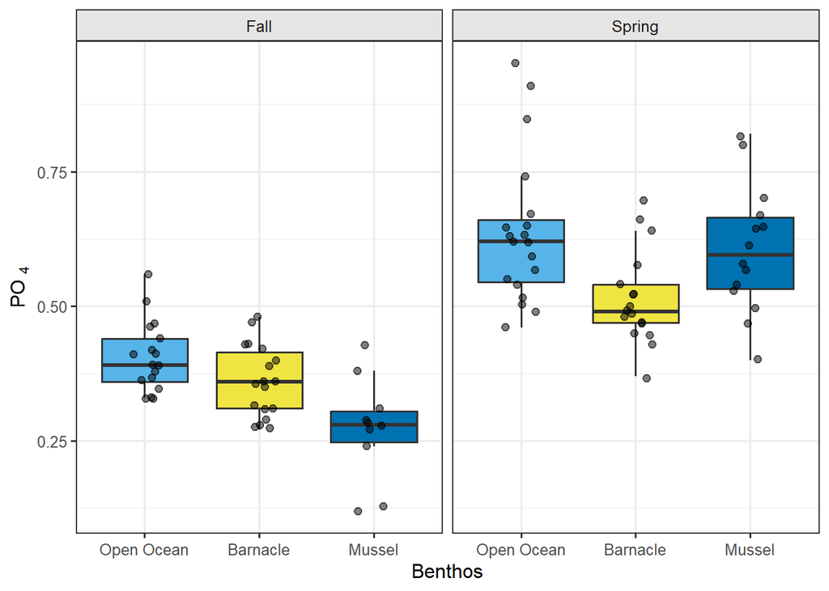

```r
# PO4 plot
animal_data %>%
    ggplot(aes(x = Benthos, y = PO4, fill = Benthos)) +
    geom_boxplot(outlier.shape = NA) +
    geom_jitter(width = 0.15, alpha = 0.5, size = 2) +
    facet_wrap(~Season) +
    scale_fill_manual(values = c("Open Ocean" = "#56B4E9", "Mussel" = "#0072B2", "Barnacle" = "#F0E442")) +
    labs(x = "Benthos", y = expression("PO "[4])) +
    theme(legend.position = "none", strip.background = element_rect(fill = "grey90"))
```

*Testing hypothesis 4:* Calcification (mussel/barnacle) increases during the day, and decreases at night, as shown by higher TA at Dawn vs Dusk.

```r
animal_data %>%
  group_by(Season) %>%
  wilcox_test(TA ~ Benthos, p.adjust.method = "bonferroni")
```

```
## # A tibble: 6 × 10
##   Season .y.   group1  group2    n1    n2 statistic       p   p.adj p.adj.signif
## * <chr>  <chr> <chr>   <chr>  <int> <int>     <dbl>   <dbl>   <dbl> <chr>
## 1 Fall   TA    Open O… Barna…    41    14      512  2.28e-6 6.84e-6 ****
## 2 Fall   TA    Open O… Mussel    41    13      371  3.4 e-2 1.03e-1 ns
## 3 Fall   TA    Barnac… Mussel    14    13       64  2.02e-1 6.06e-1 ns
## 4 Spring TA    Open O… Barna…    21    19      291  1.3 e-2 3.8 e-2 *
## 5 Spring TA    Open O… Mussel    21    29      438. 9   e-3 2.8 e-2 *
## 6 Spring TA    Barnac… Mussel    19    29      302  5.87e-1 1   e+0 ns
```

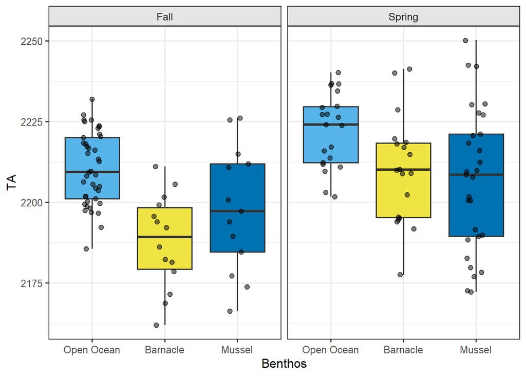

```r
# TA plot
animal_data %>%
    ggplot(aes(x = Benthos, y = TA, fill = Benthos)) +
    geom_boxplot(outlier.shape = NA) +
    geom_jitter(width = 0.15, alpha = 0.5, size = 2) +
    facet_wrap(~Season) +
    scale_fill_manual(values = c("Open Ocean" = "#56B4E9", "Mussel" = "#0072B2", "Barnacle" = "#F0E442")) +
    labs(x = "Benthos", y = "TA") +
    theme(legend.position = "none", strip.background = element_rect(fill = "grey90"))
```

# Diel variability

Start by calculating diel variability and checking missing data

```r
# calculate Δvariable
diel_data <- map_dfr(all_numeric_vars, function(v){
  data_clean %>%
    group_by(Season, Benthos, Day_Night, Quad_ID) %>%
    summarize(mean = mean(.data[[v]], na.rm = TRUE), .groups = "drop") %>%
    pivot_wider(names_from = Day_Night, values_from = mean) %>%
    mutate(
      Dusk = as.numeric(Dusk),
      Dawn = as.numeric(Dawn),
      delta_diel = Dusk - Dawn,
      variable = v)
  })

# how much sample size are we losing because of diel calculation?
missing_diel <- diel_data %>%
  filter(Benthos != "Open Ocean")

missing_diel <- missing_diel[!complete.cases(missing_diel), ]

missing_diel # honestly there's a good amount of data missing
```

```
## # A tibble: 109 × 7
##    Season Benthos   Quad_ID   Dawn   Dusk delta_diel variable
##    <chr>  <fct>     <chr>    <dbl>  <dbl>      <dbl> <chr>
##  1 Fall   Rockweed  RW5      33.4  NaN           NaN Salinity
##  2 Fall   Mussel    M3       NA     33.1          NA Salinity
##  3 Fall   Mussel    M4       NA     33.5          NA Salinity
##  4 Spring Surfgrass P3      NaN     33.2         NaN Salinity
##  5 Spring Surfgrass P5      NaN     33.2         NaN Salinity
##  6 Spring Barnacle  B3      NaN     33.8         NaN Salinity
##  7 Fall   Rockweed  RW5       7.86 NaN           NaN pH
##  8 Fall   Mussel    M3       NA      8.15         NA pH
##  9 Fall   Mussel    M4       NA      8.06         NA pH
## 10 Fall   Mussel    M3       NA     19.2          NA TempInSitu
## # ℹ 99 more rows
```

## ANOVAs

Run ANOVAs - strong seasonal responses for nutrients + pH

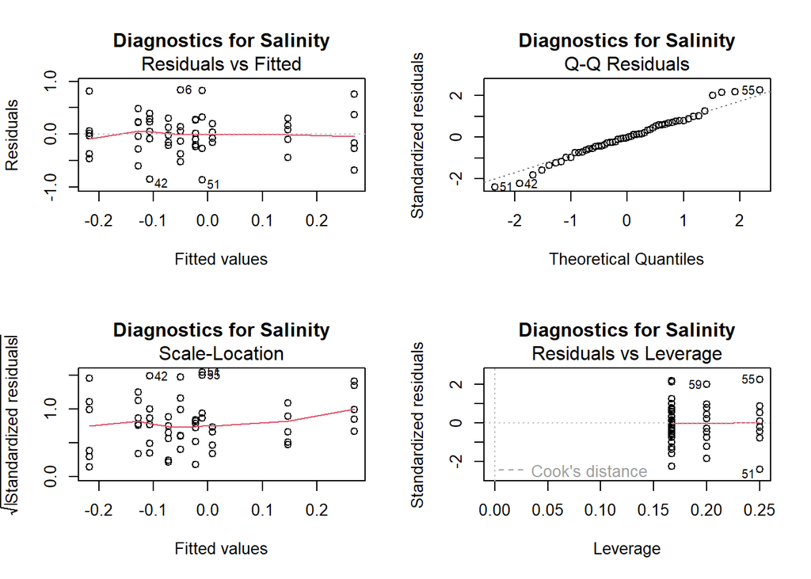

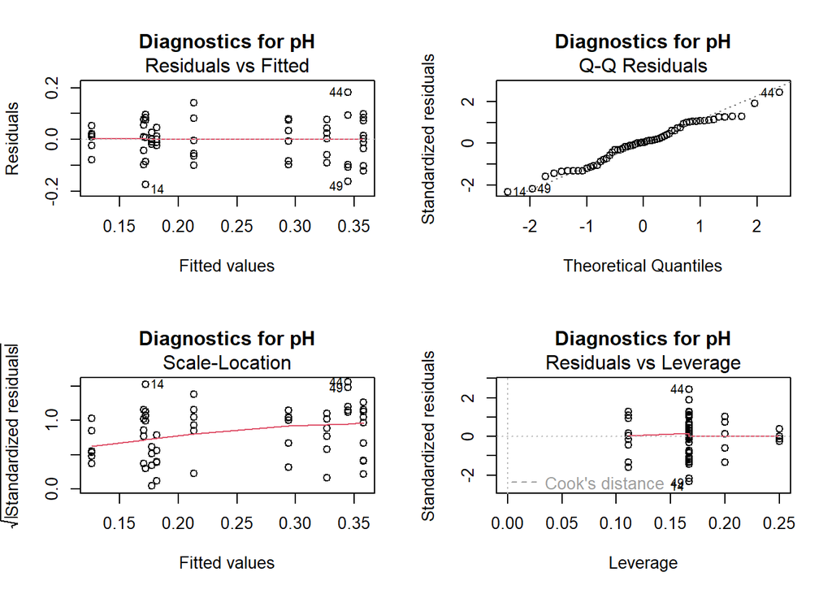

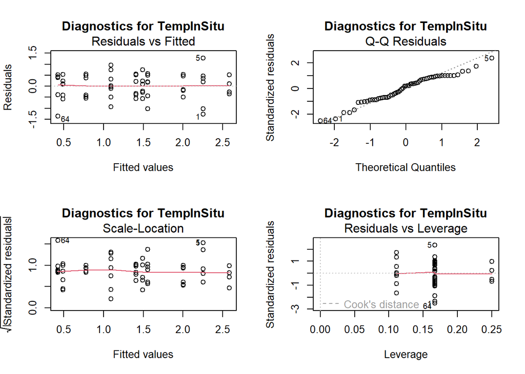

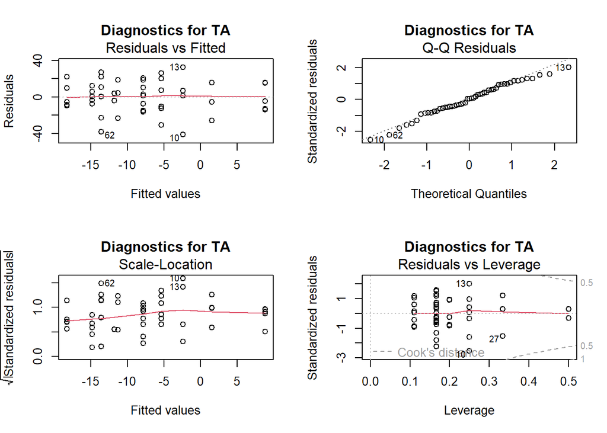

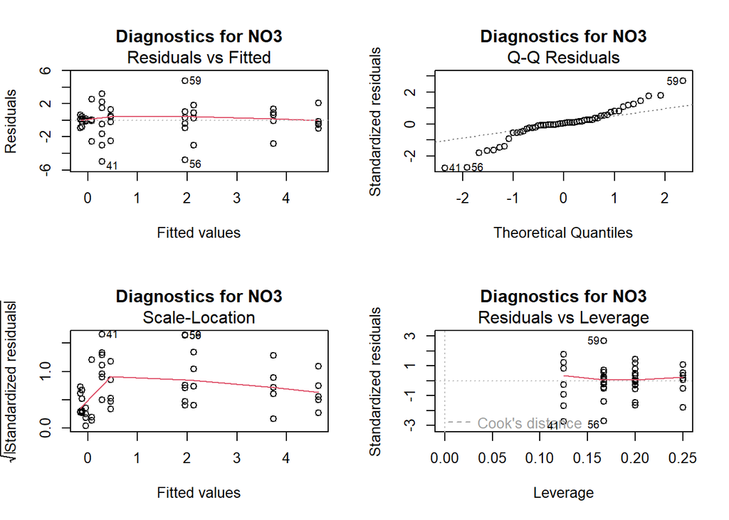

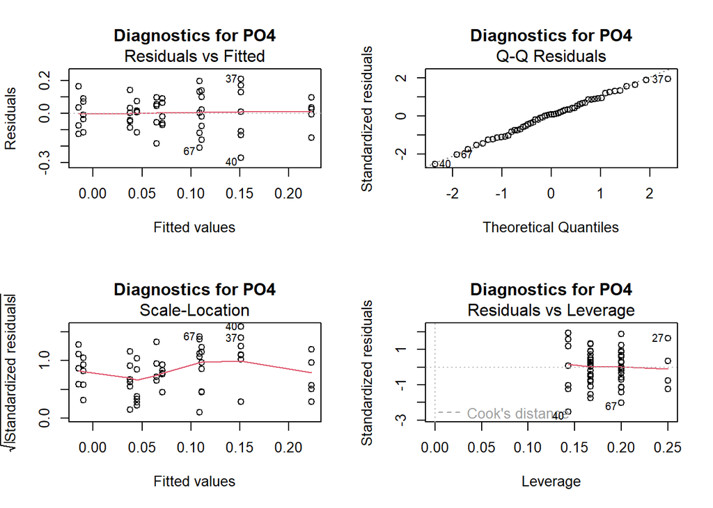

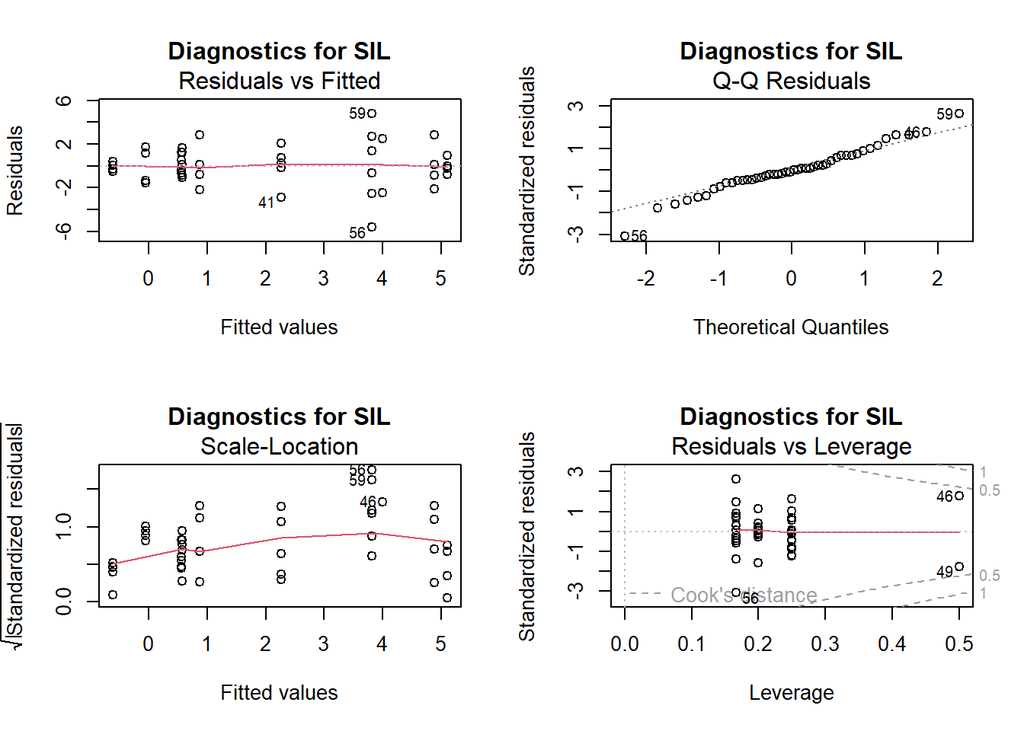

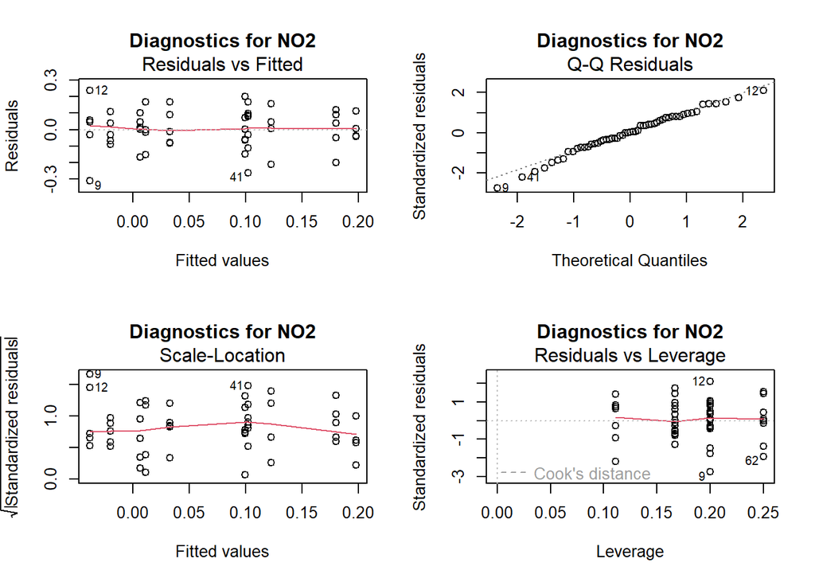

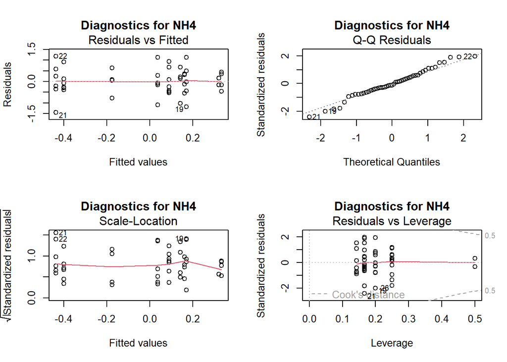

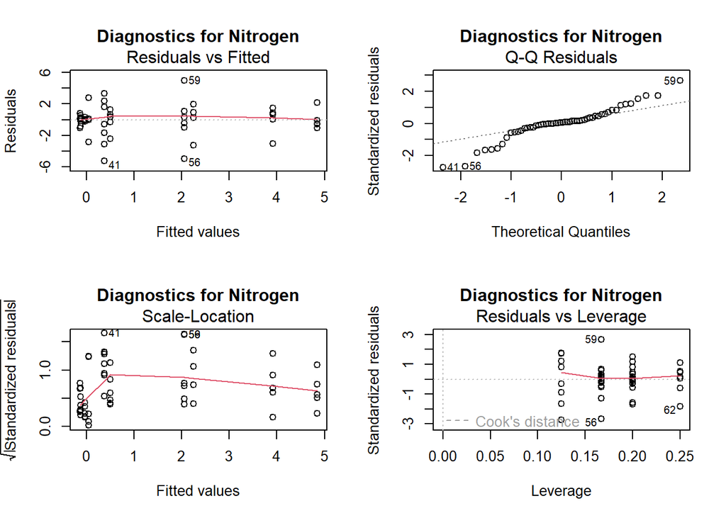

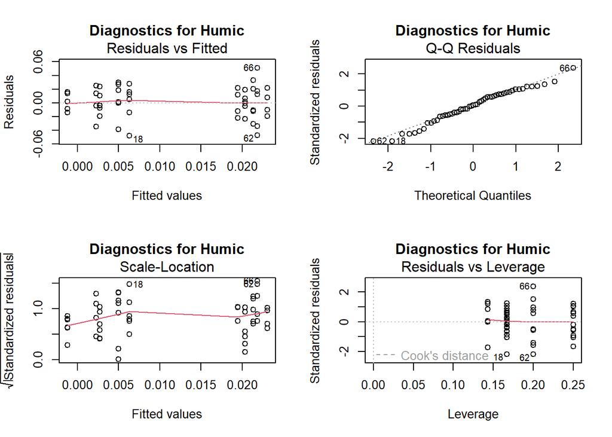

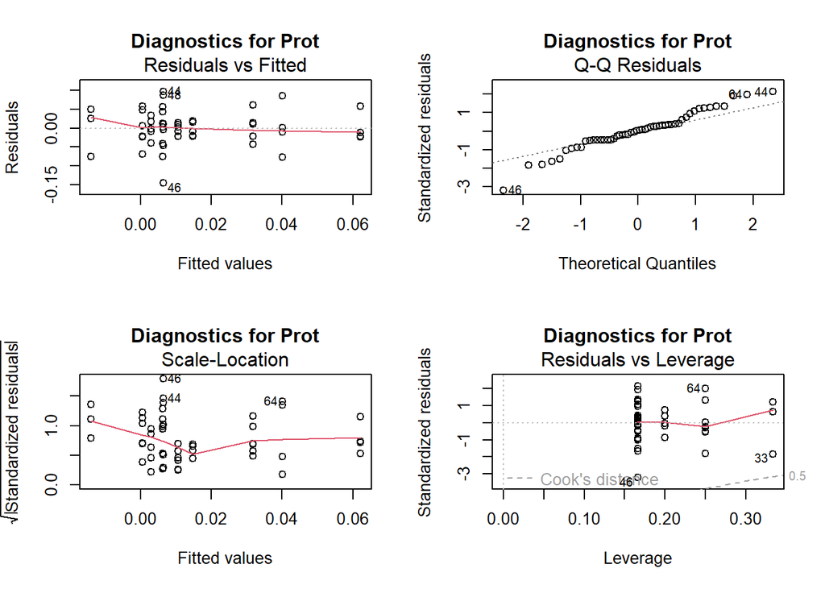

[3 more figures not shown]

```
## # A tibble: 0 × 0
```

```r
## calculating diel variability per plot
diel_data <- map_dfr(all_numeric_vars, function(v){
  data_clean %>%
    group_by(Season, Benthos, Day_Night, Quad_ID) %>%
    summarize(mean = mean(.data[[v]], na.rm = TRUE), .groups = "drop") %>%
    tidyr::pivot_wider(names_from = Day_Night, values_from = mean) %>%
    mutate(
      Dusk  = as.numeric(Dusk),
      Dawn  = as.numeric(Dawn),
      delta_diel = Dusk - Dawn,
      variable = v,
      Season = as.factor(Season)
    )
})

# running lm and creating diagnostic plots
map_dfr(all_numeric_vars, function(v){
  df_sub <- diel_data %>%
    filter(variable == v) # filter by variable
    options(contrasts = c("contr.sum", "contr.poly"))
    fit <- lm(delta_diel ~ Benthos * Season, data = df_sub)
  par(mfrow = c(2,2)) # create 2x2 for plots
  plot(fit, main = paste("Diagnostics for", v)) # check assumptions using qq and residuals plots
})
```

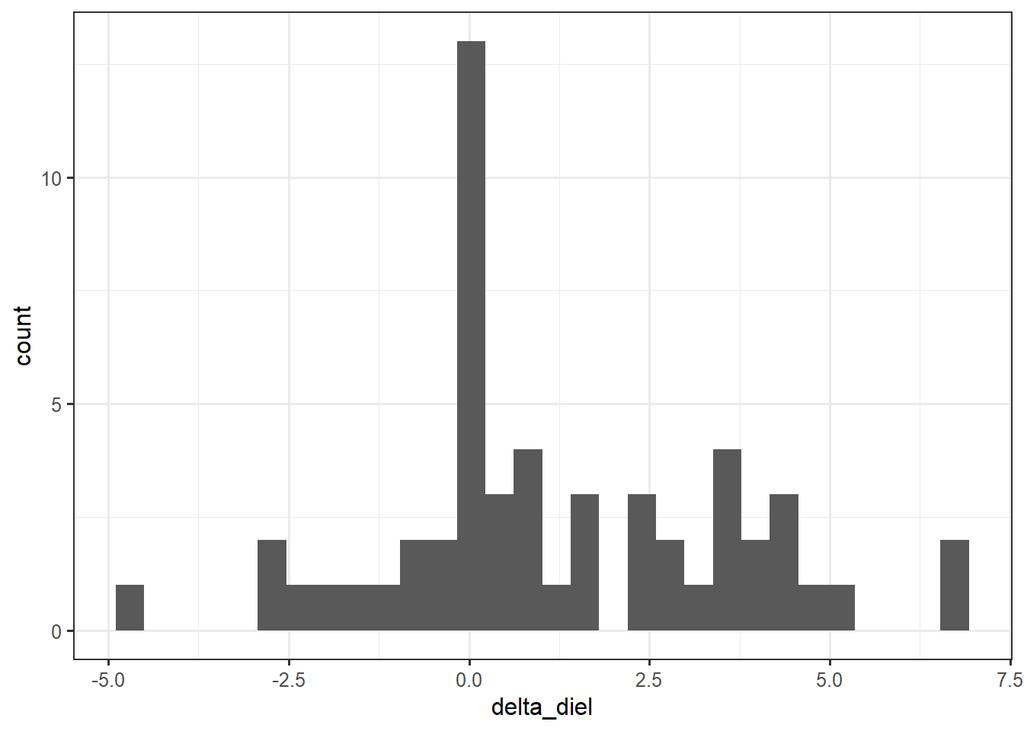

```r
# okay NO3 looks like it needs to be transformed

# NO3 diel diff is zero inflated
diel_data %>%
  filter(variable == "NO3") %>%
  ggplot(aes(delta_diel))+
  geom_histogram()
```

```r
# let's transform NO3 here so it works in our workflow later
diel_data_NO3 <- diel_data %>%
  filter(variable == "NO3") %>%
  mutate(delta_diel = sqrt(delta_diel),
         variable = "NO3_transformed")
```

```r
diel_data <- bind_rows(diel_data, diel_data_NO3)

nutrient_vars <- c("NO3_transformed", "PO4", "SIL", "NO2", "NH4", "Nitrogen")
all_numeric_vars_normal <- c(water_chem_vars, nutrient_vars, fdom_vars)

# let's see all ANOVA results together
anovas_full <- map_dfr(all_numeric_vars_normal, function(v){
  df_sub <- diel_data %>%
    filter(variable == v) # filter by variable
    options(contrasts = c("contr.sum", "contr.poly"))
    fit <- lm(delta_diel ~ Benthos * Season, data = df_sub)
    Anova(fit, type = "III") %>%
    as.data.frame() %>%
    rownames_to_column("term") %>%
    filter(term != "(Intercept)") %>%
    filter(`Pr(>F)` < 0.05) %>% # see what's significant
    mutate(variable = v)
})

anovas_full # looks like season is main driver here, one season:benthos interaction with temp
```

```
##             term      Sum Sq Df  F value       Pr(>F)        variable
## 1         Season   0.2905150  1 43.05083 2.915198e-08              pH
## 2         Season  19.0697269  1 54.13826 1.482104e-09      TempInSitu
## 3 Benthos:Season   6.6184008  4  4.69735 2.643182e-03      TempInSitu
## 4         Season   9.6216593  1 51.67678 9.896306e-08 NO3_transformed
## 5         Season   0.1518756  1 11.30734 1.584264e-03             PO4
## 6         Season 146.2067289  1 36.80621 5.659016e-07             SIL
## 7         Season   0.2625157  1 16.31976 2.060689e-04             NO2
## 8         Season  90.5984958  1 21.76605 2.886504e-05        Nitrogen
## 9         Season  11.0272093  1 12.95818 7.768462e-04             HIX
```

```r
# what if i get rid of interaction
anovas <- map_dfr(all_numeric_vars_normal, function(v){
  df_sub <- diel_data %>%
    filter(variable == v) # filter by variable
    options(contrasts = c("contr.sum", "contr.poly"))
    fit <- lm(delta_diel ~ Benthos + Season, data = df_sub)
    Anova(fit, type = "III") %>%
    as.data.frame() %>%
    rownames_to_column("term") %>%
    filter(term != "(Intercept)") %>%
    filter(`Pr(>F)` < 0.05) %>% # see what's significant
    mutate(variable = v)
})

anovas # okay, looks identical without interaction
```

```
##     term      Sum Sq Df  F value       Pr(>F)        variable
## 1 Season   0.3033448  1 42.36227 2.581921e-08              pH
## 2 Season  18.0472226  1 40.37787 4.283124e-08      TempInSitu
## 3 Season  11.2044208  1 59.74299 1.016085e-08 NO3_transformed
## 4 Season   0.1489101  1 11.80427 1.212812e-03             PO4
## 5 Season 150.0028731  1 35.90202 4.853163e-07             SIL
## 6 Season   0.2518358  1 16.10088 2.050970e-04             NO2
## 7 Season  80.0910303  1 17.01250 1.466210e-04        Nitrogen
## 8 Season  11.6990866  1 14.27640 4.211022e-04             HIX
```